# Zadanie3

A.Brodecka, M.Stolarczyk

26 marca 2017

```r
setwd('C:/Users/ola/Desktop/wb')

library(rworldmap)
library(dplyr)
library(ggplot2)
library(tidyr)
library(knitr)
cbPalette <- c("#E69F00", "#56B4E9", "#009E73", "#ad2803", "#0072B2", "#D55E00", "#CC79A7")
data <- readRDS('PodstawoweStatystyki.rds')
data$TimeMed <- data$TimeMed/1000
```

## Streszczenie

Poniższy dokument przedstawia klasteryzację państw względem ważonej mediany czasów rozwiązań oraz proporcji dobrze rozwiązanych zadań. W analizie grupowania państw zastosowano metodę Warda.

## Analiza:

- Krok 0: Budujemy statystyki ważone dla każdego pytania w podziale na kraje. (zbiór PodstawoweStatystyki.rds)
- Dokonujemy standaryzacji kolumn powyższego zbioru
- Budujemy dendogram dla kazdej kategorii, który porównuje ważoną medianę czasów rozwiązań dla każdego pytania i proporcję dobrze rozwiązanych zadań w podziale na kraje.
- Używamy tylko kolumn bez braków danych.
- W celu narysowania boxplotów i przedstawienia wyników mediany czasów rozwiązań dokonaliśmy zmiany jednostki z milisekund na sekundy.

## Matematyka:

```r
mat <- data %>% filter(substr(item, 2,2) == "M") %>% select(item, TimeMed, CNT, FreqFull)

mat %>% select(item, TimeMed, CNT)  %>% spread(item, TimeMed) -> mat_clust
mat %>% select(item,  FreqFull, CNT)  %>% mutate(FreqFull =  FreqFull) %>% spread(item,  FreqFull) -> mat_clust_prop

colnames(mat_clust_prop)[-1] <- paste0('Freq',colnames(mat_clust_prop)[-1])

mat_clust <- mat_clust %>% left_join(mat_clust_prop)

mat_clust <- mat_clust[ , colSums(is.na(mat_clust)) == 0]
rownames(mat_clust) <- mat_clust[,1]
```

Ramka danych do klasteryzacji:

```r
mat_clust <- scale(mat_clust[,-1])
kable(head(mat_clust))
```

|  | CM033Q01 | CM034Q01 | CM155Q01 | CM155Q04 | CM273Q01 | CM305Q01 | CM408Q01 | CM411Q01 | CM411Q02 | CM420Q01 | CM423Q01 | CM442Q02 | CM446Q01 | CM447Q01 | CM464Q01 | CM474Q01 | CM496Q01 | CM496Q02 | CM559Q01 | CM564Q01 | CM564Q02 | CM571Q01 | CM603Q01 | CM800Q01 | CM803Q01 | CM828Q03 | CM906Q01 | CM909Q01 | CM909Q02 | … |
| --- | --- | --- | --- | --- | --- | --- | --- | --- | --- | --- | --- | --- | --- | --- | --- | --- | --- | --- | --- | --- | --- | --- | --- | --- | --- | --- | --- | --- | --- | --- |
| ARE | 0.2467098 | -1.0619934 | -0.0475885 | 0.0475100 | 0.0348155 | 0.6812590 | 0.3897879 | -0.2583978 | -0.9965226 | 0.5168663 | 0.4978871 | 0.0864970 | 0.1674130 | -0.3113775 | -1.0173448 | 0.3412372 | -0.1266558 | 0.5712465 | -0.1775436 | -0.3799481 | -0.4461577 | -0.1556166 | -0.2705850 | -0.5742389 | -0.0386423 | -0.8351846 | 0.2928725 | 0.4182406 | 1.4064928 | … |
| AUS | -0.4118448 | -0.6291617 | -0.2870350 | -0.4064414 | -1.1180502 | -0.7603564 | -0.8461053 | -0.6500440 | -0.3471186 | -0.5337242 | -0.4329361 | -0.4030616 | -0.6270039 | -0.6168483 | -0.2277286 | -0.4885083 | -0.3966729 | -0.5522196 | -0.5905477 | -0.3977724 | -0.6855913 | -0.4411172 | -0.5147860 | -1.0483019 | -0.6274507 | -0.3039125 | -0.3364972 | -0.5291151 | -0.5578900 | … |
| AUT | -0.5906710 | -0.0624793 | -0.2752998 | -0.1137067 | -0.7811812 | -0.6539462 | -0.2963089 | -0.6131062 | -0.0250937 | -0.0700307 | 0.1649670 | -0.2744133 | 0.1072575 | -0.4578194 | 0.7302208 | -0.4332504 | -0.3768801 | -0.6624674 | -0.1411691 | -0.4875528 | -0.2812747 | 0.4813306 | 0.2951765 | -0.4565157 | -0.3776706 | -0.5027643 | -0.3092324 | -0.2747557 | -0.9785999 | … |
| BEL | -0.1531580 | 0.3354202 | -0.3485107 | 0.3069126 | -0.0317607 | -0.4630597 | 0.1770791 | 0.1247769 | 0.7919788 | -0.2254800 | 0.8090626 | 0.0506644 | -0.0541030 | -0.3058053 | 0.8452638 | -0.2349623 | -0.2654482 | -0.3374130 | 0.5045751 | -0.0621540 | 0.9502959 | 1.4145038 | 0.8362289 | -0.3114665 | 0.3111538 | 0.4713786 | 0.0638717 | -0.3516121 | -0.5162630 | … |
| BGR | 0.4880796 | 0.3795457 | -0.1965120 | 0.3052877 | 0.5841247 | 0.2369608 | 0.5460612 | 0.7607057 | 0.3324929 | 1.1397304 | 0.6511879 | 0.2689630 | 0.8774036 | 0.7892400 | 0.4534886 | 1.2044017 | -0.0858729 | 0.0183742 | 0.6287001 | 0.7945312 | -0.1453375 | 0.0474750 | 0.9497749 | 0.6585796 | 0.1085773 | 0.1499404 | 0.4406203 | 0.7444691 | -0.0793236 | … |
| BRA | 2.8006000 | 0.7849033 | 2.2197947 | 1.9729507 | 1.7925743 | 1.7321570 | 1.6967251 | 1.3973906 | 1.9807614 | 1.9269195 | 2.6206562 | 0.2297064 | 2.3477362 | 2.3392016 | 0.6530910 | 2.4184449 | 2.2416564 | 2.4411903 | 1.3808911 | 1.6519535 | 0.8381240 | -0.2521400 | -0.0454937 | 1.3126801 | 2.6328917 | 0.8526646 | 1.4080012 | 2.4811406 | 1.9945912 | … |

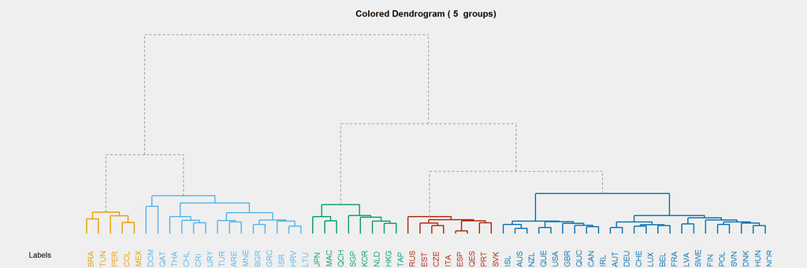

```r
hc = hclust(dist(mat_clust), method = "ward.D")
klasy <- data.frame(class = cutree(hc, k = 5), CNT = names(cutree(hc, k = 5)))
mat <- mat %>% left_join(klasy)


mat$CNT <- reorder(mat$CNT, mat$class)

op = par(bg = "#EFEFEF")
A2Rplot(hc, k = 5, boxes = FALSE, col.up = "gray50", col.down = cbPalette)
```

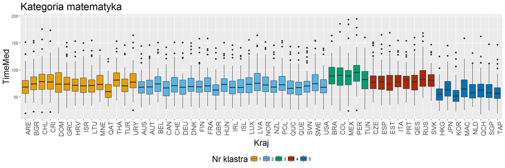

```r
ggplot(mat, aes(factor(CNT), TimeMed, fill = as.factor(class))) + geom_boxplot() +
  scale_fill_manual(values=cbPalette, name = "Nr klastra") + labs(x = "Kraj") +
  theme(legend.position="bottom") + ggtitle('Kategoria matematyka') + theme(title = element_text(size = 18),
  axis.text.x = element_text(angle = 90, hjust = 1, size = 14))
```

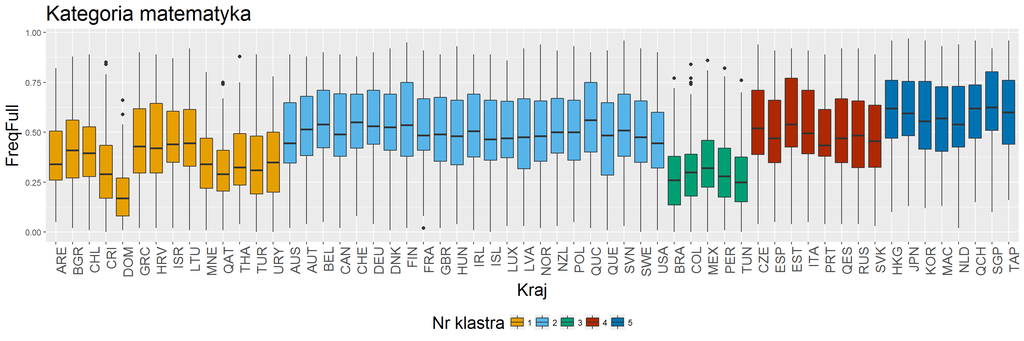

```r
ggplot(mat, aes(factor(CNT), FreqFull, fill = as.factor(class))) + geom_boxplot() + scale_fill_manual(values=cbPalette, name = "Nr klastra") + labs(x = "Kraj") +
  theme(legend.position="bottom") + ggtitle('Kategoria matematyka') + theme(title = element_text(size = 18),
  axis.text.x = element_text(angle = 90, hjust = 1, size = 14))
```

```r
klasy$class <- as.factor(klasy$class)
spdf <- joinCountryData2Map(klasy, joinCode="NAME", nameJoinColumn="CNT")
```

```
FALSE 53 codes from your data successfully matched countries in the map
FALSE 5 codes from your data failed to match with a country code in the map
FALSE 190 codes from the map weren't represented in your data
```

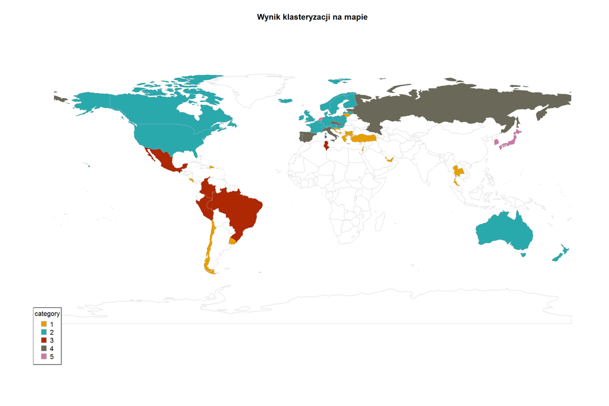

```r
mapCountryData(spdf, nameColumnToPlot="class", catMethod="fixedWidth", mapTitle =  'Wynik klasteryzacji na mapie',
               colourPalette =cbPalette )
```